# Team All Stars Lab 4

Johnny Tamanaha, Emily Archambault, Eugene Miller, Kaiyuan Fan, Jingzhi Zhang

9/20/2019

### Preliminary Question

Which variables are similar between smokers and nonsmokers? Which are different?

### Correlating Birth Weight (difference)

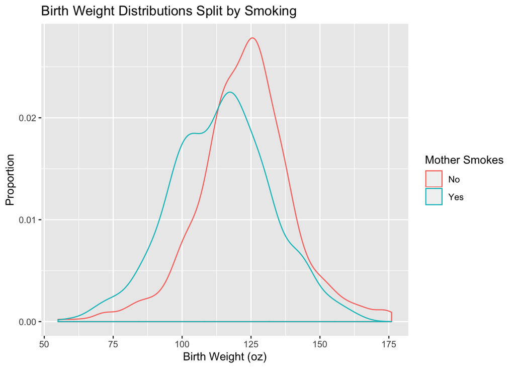

```r
ggplot(subset(babies, smoke != "NA")) +
  geom_density(mapping=aes(x = bwtoz, color = smoke==1)) +
  labs(title="Birth Weight Distributions Split by Smoking") +
  xlab("Birth Weight (oz)") +
  ylab("Proportion") +
  scale_color_discrete(name="Mother Smokes", labels=c("No", "Yes"))
```

### Income (no difference)

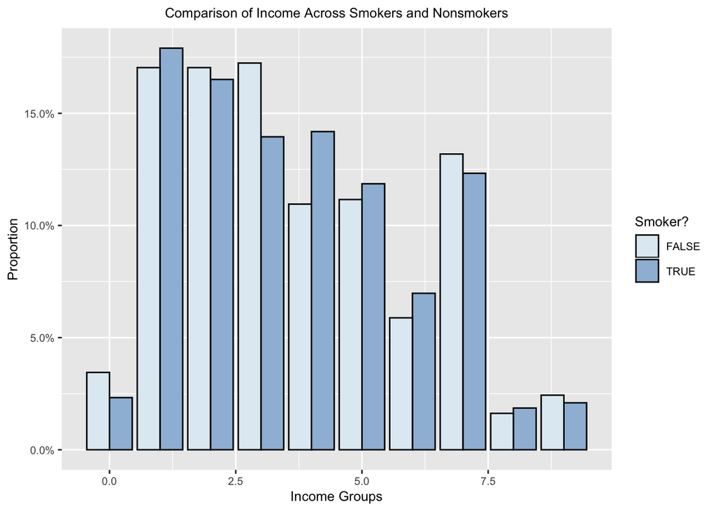

```r
ggplot(subset(babies, smoke != "NA")) +
  geom_bar(mapping = aes(x = inc, y = ..prop.., fill = smoke == 1), position = "dodge", color = "black") +
  theme(text = element_text(hjust = 0.5, size = 9.5), plot.title = element_text(hjust = 0.5, size = 9.5)) +
  scale_y_continuous(labels=scales::percent) +
  labs(x = "Income Groups", y = "Proportion", fill = "Smoker?", title = "Comparison of Income Across Smokers and Nonsmokers") +
  scale_fill_brewer(palette = 3)
```

### Premature births (difference)

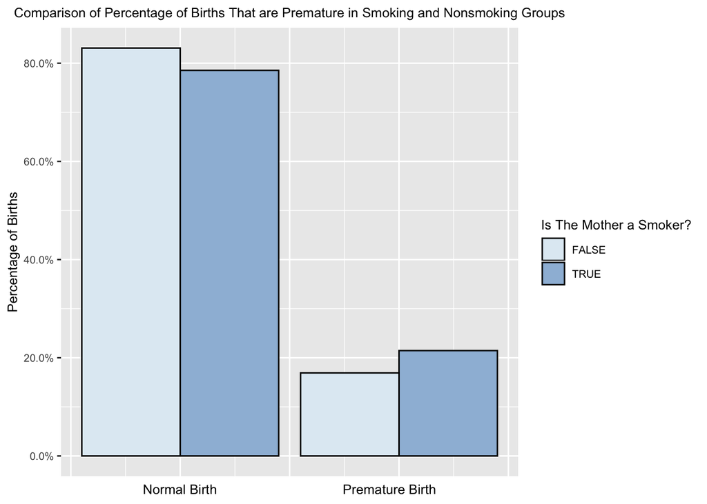

```r
ggplot(subset(babies, smoke != "NA")) +
  geom_bar(mapping = aes(x = Premature, y = ..prop.., fill = smoke == 1), position = "dodge", color = "black") +
  scale_y_continuous(labels=scales::percent) +
  labs(y = "Percentage of Births", fill = "Is The Mother a Smoker?", x = "Normal Birth                                  Premature Birth", title = "Comparison of Percentage of Births That are Premature in Smoking and Nonsmoking Groups") +
  theme(axis.text.x=element_blank(), axis.ticks.x=element_blank(), text = element_text(hjust = 0.5, size = 9.5), plot.title = element_text(hjust = 0.5, size = 9.5)) +
  scale_fill_brewer(palette = 3)
```

### Correlating age (difference)

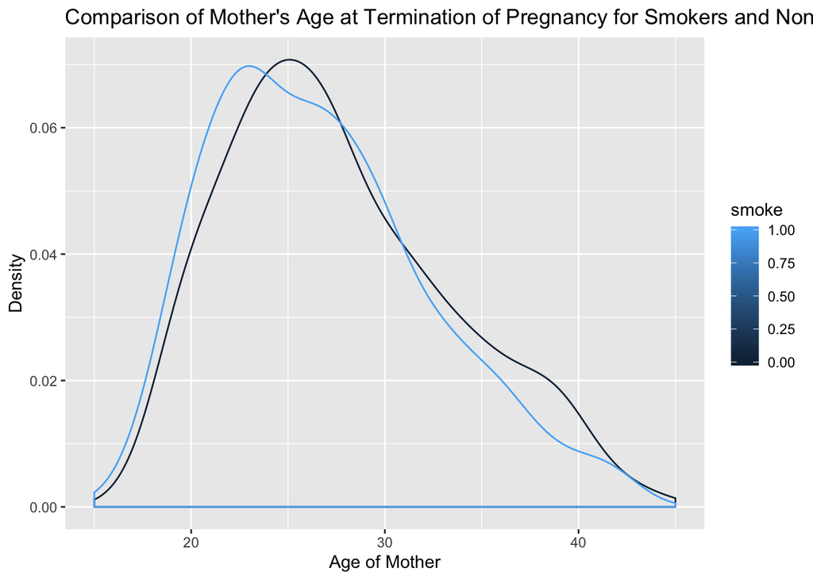

```r
ggplot(subset(babies, smoke != "NA")) +
geom_density(mapping = aes(x = mage, group = smoke, color = smoke)) +
labs(x = "Age of Mother", y = "Density", title = "Comparison of Mother's Age at Termination of Pregnancy for Smokers and Non-Smokers")
```

### Correlating Race (difference)

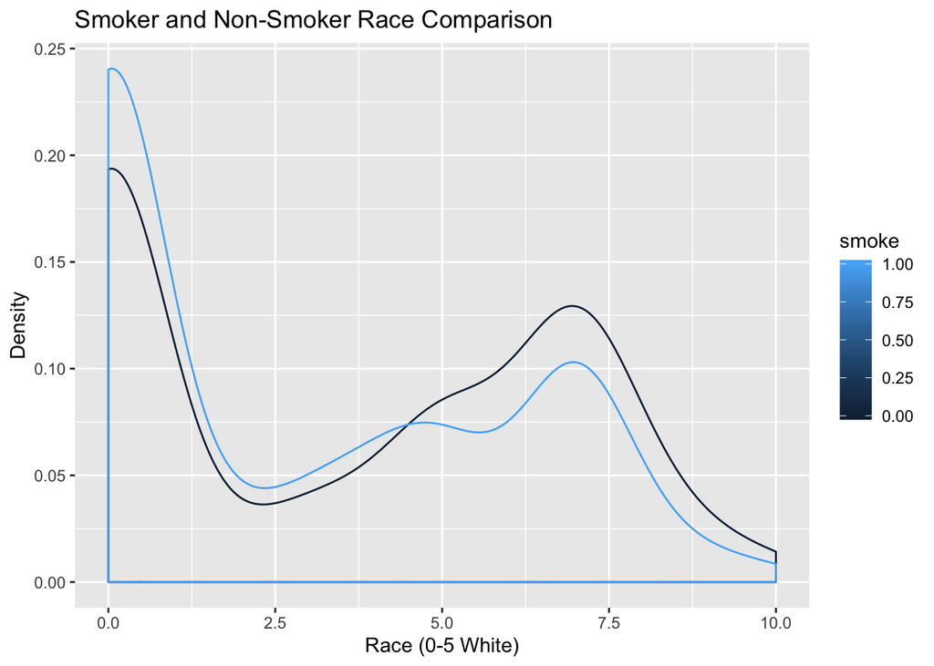

```r
ggplot(subset(babies, smoke != "NA")) +
geom_density(mapping = aes(x = mrace, group = smoke, color=smoke)) +
labs(x = "Race (0-5 White)", y = "Density", title = "Smoker and Non-Smoker Race Comparison")
```

### Two Main Questions

Do mothers who smoke have increased rates of premature delivery (before 270 days)?

Do the newborns of mothers who smoke have smaller birth weights at every gestational age (number of days into pregnancy when child is born)?

## Overall Questions, why they are important, and why those reasons are important.

Analyzing how a mother’s smoking habits affect their child’s birth timing and weight is important because having that knowledge would help people make better decisions for the health of the next generation. Not only would this help lawmakers take action or doctors spread awareness about the health risks of smoking for pregnant women, but it would help pregnant women be informed about the risks that smoking has on their children.